# VCF linear model

Bastei

Friday, January 16, 2015

# Data exploration & preprocessing

Loading required library

```r
library(raster)
```

Loading Landsat files:

```r
load("data/GewataB1.rda")
load("data/GewataB2.rda")
load("data/GewataB3.rda")
load("data/GewataB4.rda")
load("data/GewataB5.rda")
load("data/GewataB7.rda")
load("data/vcfGewata.rda")

Gewata <- stack(GewataB1,GewataB2,GewataB3,GewataB4,GewataB5,GewataB7, vcfGewata)
names(Gewata) <- c('band1', 'band2', 'band3', 'band4', 'band5', 'band7', 'VCF')
```

Histograms of Gewata show that in many bands outliers are present:

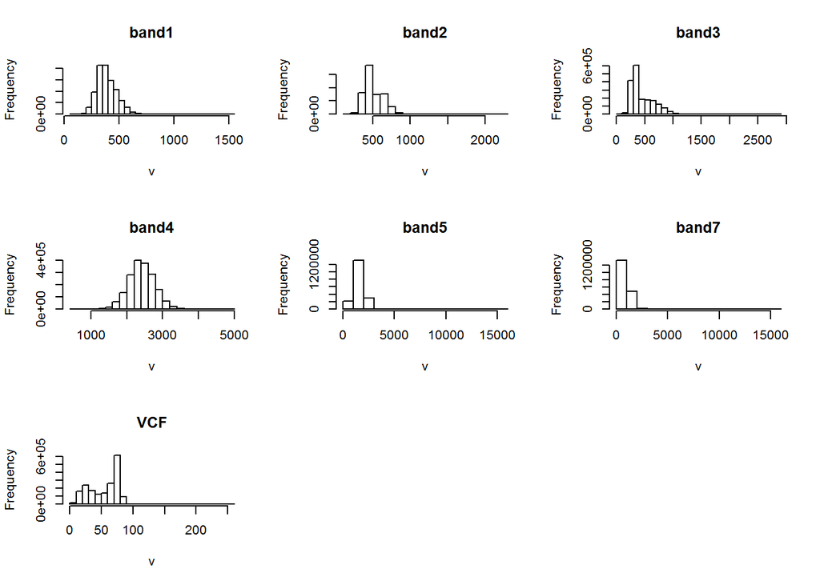

Clearing plot area

```r
dev.off()
```

Therefore, all values higher or lower than the mean +/- 5*sd are set to NA:

```r
mean <- cellStats(x = Gewata, stat = 'mean')
sd5 <- 5*(cellStats(x = Gewata, stat = 'sd'))
lowerbound <- mean - sd5
upperbound <- mean + sd5
Gewata[Gewata > upperbound] <- NA
Gewata[Gewata < lowerbound] <- NA
```

The new histograms look much better:

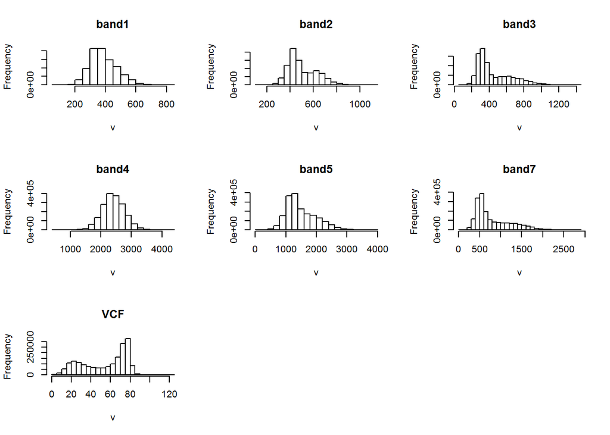

Clearing plot area

```r
dev.off()
```

Plots that demonstrate the relationship between the Landsat bands and the VCF tree cover:

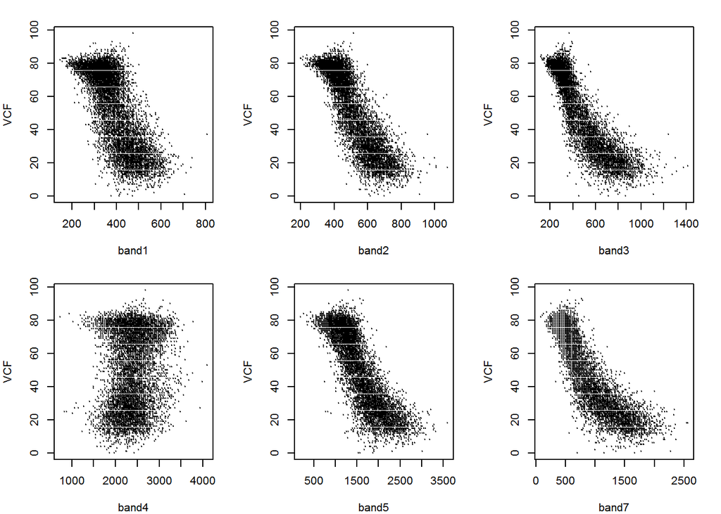

*From the plots we conclude that band 4 does not seem to explain much of the variance in VCF, while the other bands seem to have a negative relationship with VCF.*

We create a dataframe without rows containing NA values

```r
GewataDF <- as.data.frame(Gewata)
GewataDF <- na.omit(GewataDF)
```

# Linear Model

Creating multilinear model for VCF prediction based on bands as covariables

```r
modelLM <- lm(VCF ~ band1 + band2 + band3 + band4 + band5 + band7, data = GewataDF)
```

model summary:

```
##
## Call:
## lm(formula = VCF ~ band1 + band2 + band3 + band4 + band5 + band7,
##     data = GewataDF)
##
## Residuals:
##     Min      1Q  Median      3Q     Max
## -57.987  -4.631   0.709   5.204  55.866
##
## Coefficients:
##               Estimate Std. Error t value Pr(>|t|)
## (Intercept)  8.596e+01  5.738e-02 1498.03   <2e-16 ***
## band1        9.273e-02  1.887e-04  491.42   <2e-16 ***
## band2       -1.514e-01  2.354e-04 -643.19   <2e-16 ***
## band3       -2.121e-03  1.747e-04  -12.14   <2e-16 ***
## band4        1.633e-02  2.842e-05  574.66   <2e-16 ***
## band5       -1.909e-02  7.439e-05 -256.59   <2e-16 ***
## band7       -1.131e-03  9.843e-05  -11.49   <2e-16 ***
## ---
## Signif. codes:  0 '***' 0.001 '**' 0.01 '*' 0.05 '.' 0.1 ' ' 1
##
## Residual standard error: 8.577 on 1807935 degrees of freedom
## Multiple R-squared:  0.8591, Adjusted R-squared:  0.8591
## F-statistic: 1.838e+06 on 6 and 1807935 DF,  p-value: < 2.2e-16
```

Model coefficients:

```
##
## Call:
## lm(formula = VCF ~ band1 + band2 + band3 + band4 + band5 + band7,
##     data = GewataDF)
##
## Coefficients:
## (Intercept)        band1        band2        band3        band4
##   85.960883     0.092733    -0.151380    -0.002121     0.016334
##       band5        band7
##   -0.019089    -0.001131
```

# Model quality

First, we make a new VCF raster, based on prediction modelLM:

```r
covs <- Gewata[[1:6]]
VCFpred <- predict(covs, model = modelLM, na.rm = T)
```

Comparison of original VCF map and predicted VCF map:

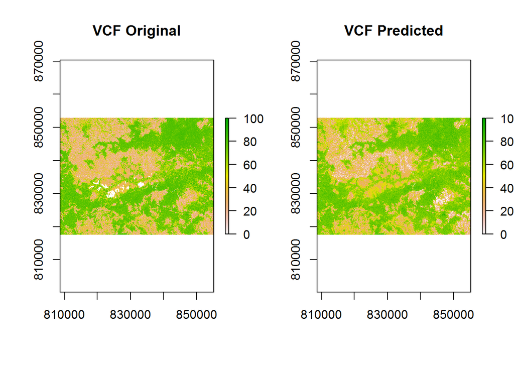

Calculation of differences between original VCF and predicted VCF and RMSE and its plot

```r
VCFres <- VCFpred - Gewata[[7]]
```

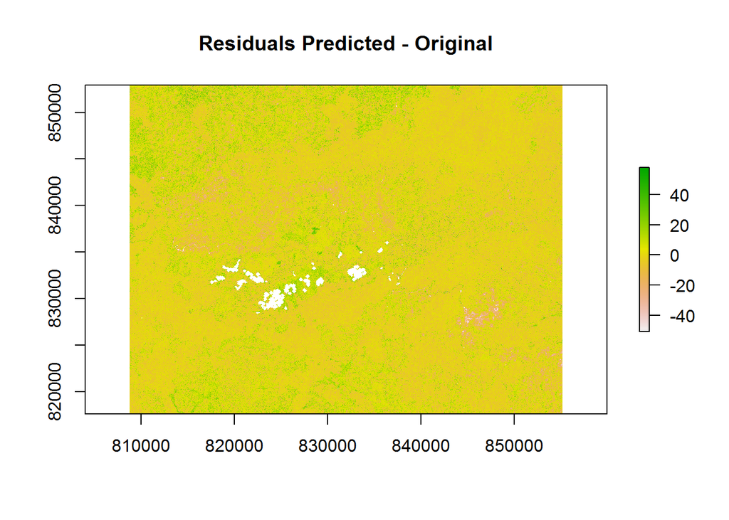

**RMSE calculation**

```r
VCFresDF <- as.data.frame(VCFres)
VCFresDF <- na.omit(VCFresDF)
RMSE <- (mean(VCFresDF**2))**0.5
```

**Result**

```
## [1] 8.576827
```

# Calculation RMSE per class

Loading training data of classes:

```r
load("data/trainingPoly.rda")
```

Converting classes to integer values:

```r
trainingPoly@data$Code <- as.numeric(trainingPoly@data$Class)
```

Assigning ‘Code’ values to raster cells (where they overlap):

```r
classes <- rasterize(trainingPoly, Gewata, field='Code')
```

Map of training data

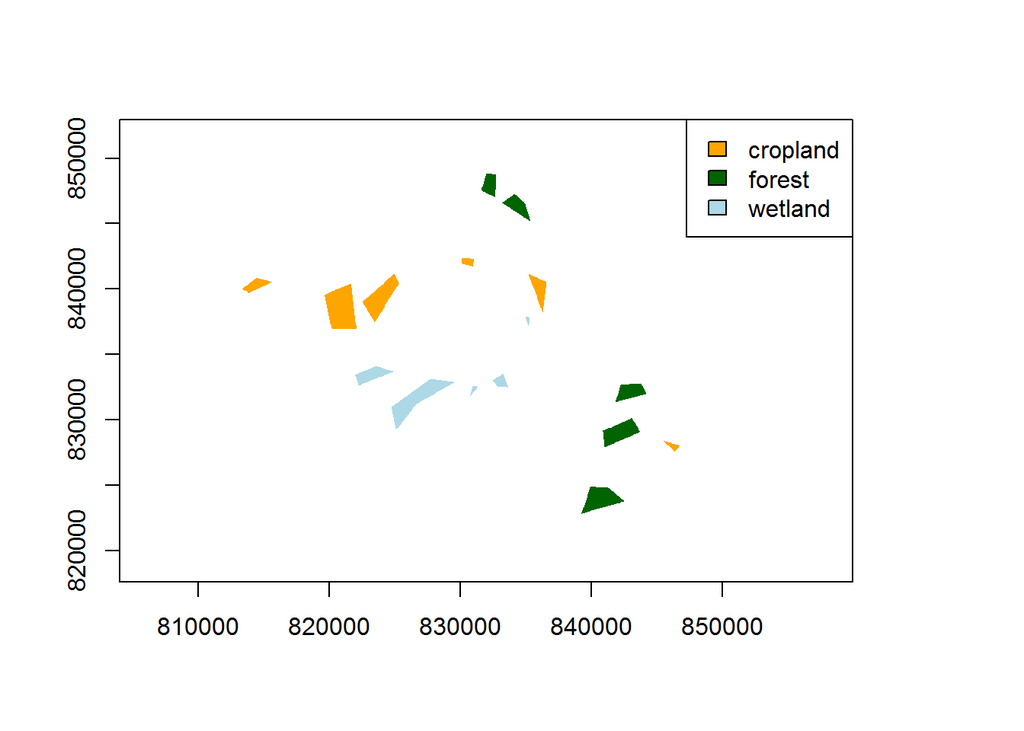

```r
# define a colour scale for the classes (as above)
# corresponding to: cropland, forest, wetland
cols <- c("orange", "dark green", "light blue")

plot(classes, col=cols, legend=FALSE)
# add a customized legend
legend("topright", legend=c("cropland", "forest", "wetland"), fill=cols, bg="white")
```

**RMSE calculation per class**

```r
RS_VCFres <- (VCFres**2)
RMSEclass <- zonal(RS_VCFres, classes, fun='mean', digits=0, na.rm=TRUE)
RMSEclass[,2] <- RMSEclass[,2]**0.5
RMSE_Table <- as.data.frame(RMSEclass)
labs <- c("Cropland", "Forest", "Wetland")
RMSE_Table$zone <- labs
```

Result:

```
##       zone      mean
## 1 Cropland 10.070404
## 2   Forest  4.973587
## 3  Wetland 11.832641
```

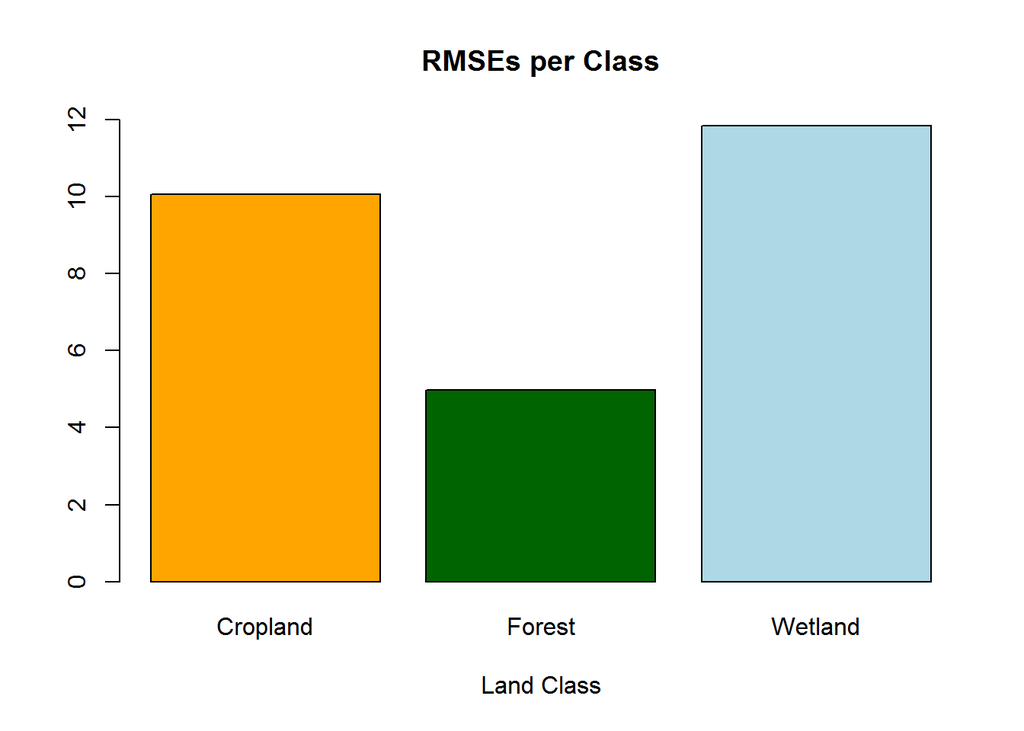

**CONCLUSION: RMSE indicates that modelLM predicts VCF with the highest precision/accuracy for class ‘forest’. Wetland is worst predicted of the three classes based on the same model.**